# Casal2 Test Case MPD comparisons for SBW

# 1 SBW comparison of CASAL and Casal2 model configurations

This document compares the results of at least 2 CASAL model configurations (base and at least one sensitivity) and up to 6 Casal2 model configurations (3 BetaDiff and 3 ADOL-C).

The Casal2 ADOL-C and BetaDiff low tolerance models have a smaller tolerance value than the CASAL base model (1e-8 vs. 2e-6).

## 1.1 SBW model characteristics

The main characteristics of the Test Case SBW (southern blue whiting) CASAL model are:

- one stock, ages 2 - 15
- two areas, spawn and nospawn
- years 1960 - 2015, projection years 2016 - 2021
- two time steps
- two stock categories, male and female
- sex-specific migration from 'nospawn' to 'spawn'
- male and female natural mortality (M) average of 0.2, difference of 0.02
- Beverton-Holt stock-recruitment relationship, with steepness (h) 0.9 and $\sigma_R$ 1.0
- length-weight relationship ($W = aL^b$)
- no ageing error
- one fishery in area 'spawn'

Observation data include:

- empirical sex-specific length-at-age data for 1979 - 2015
- survey indices for immature and mature partitions
- fishery sex-specific proportions-at-age

Parameters estimated include:

- B0
- process error for the mature survey index
- the average of and difference between male and female natural mortality
- sex-specific migration rates
- YCS (recruitment deviations)

## 1.3 CASAL and Casal2 model output

```r
source('../../R-functions/report_read_in_CASAL_MPD_files.R')
```

```r
source('../../R-functions/report_read_in_Casal2_MPD_files.R')
```

## 1.4 Tables

Tables of parameter estimates and objective function components for the CASAL and Casal2 model MPD results

CASAL parameter estimates

| rownames | Base_Model | Sensitivity_1 | Percent_Diff |
| --- | --- | --- | --- |
| initialization.B0 | 314500.00000 | 314500.00000 | 0.000 |
| relative_abundance[TangaroaAcousticMature].cv_process_error | 0.00010 | 0.00010 | 0.000 |
| natural_mortality.avg | 0.15580 | 0.15580 | 0.000 |
| natural_mortality.diff | -0.00914 | -0.00914 | 0.000 |
| migration[toSpawn].rates_male1 | 0.08558 | 0.08558 | 0.000 |
| migration[toSpawn].rates_male2 | 0.72990 | 0.72990 | 0.000 |
| migration[toSpawn].rates_male3 | 0.51270 | 0.51270 | 0.000 |
| migration[toSpawn].rates_male4 | 0.33120 | 0.33120 | 0.000 |
| migration[toSpawn].rates_male5 | 0.99000 | 0.99000 | 0.000 |
| migration[toSpawn].rates_female1 | 0.01907 | 0.01907 | 0.000 |
| migration[toSpawn].rates_female2 | 0.51250 | 0.51250 | 0.000 |
| migration[toSpawn].rates_female3 | 0.94120 | 0.94120 | 0.000 |
| migration[toSpawn].rates_female4 | 0.99900 | 0.99900 | 0.000 |
| migration[toSpawn].rates_female5 | 0.99000 | 0.99000 | 0.000 |
| recruitment.YCS1 | 0.25590 | 0.25590 | 0.000 |
| recruitment.YCS2 | 0.26100 | 0.26100 | 0.000 |
| recruitment.YCS3 | 0.26700 | 0.26700 | 0.000 |
| recruitment.YCS4 | 0.27430 | 0.27430 | 0.000 |
| recruitment.YCS5 | 0.28320 | 0.28320 | 0.000 |
| recruitment.YCS6 | 0.29410 | 0.29410 | 0.000 |
| recruitment.YCS7 | 0.30880 | 0.30880 | 0.000 |
| recruitment.YCS8 | 0.82470 | 0.82470 | 0.000 |
| recruitment.YCS9 | 0.53160 | 0.53160 | 0.000 |
| recruitment.YCS10 | 0.37070 | 0.37070 | 0.000 |
| recruitment.YCS11 | 0.26680 | 0.26680 | 0.000 |
| recruitment.YCS12 | 0.13850 | 0.13850 | 0.000 |
| recruitment.YCS13 | 0.08025 | 0.08025 | 0.000 |
| recruitment.YCS14 | 0.15820 | 0.15820 | 0.000 |
| recruitment.YCS15 | 0.10630 | 0.10630 | 0.000 |
| recruitment.YCS16 | 0.05757 | 0.05757 | 0.000 |
| recruitment.YCS17 | 0.06079 | 0.06079 | 0.000 |
| recruitment.YCS18 | 0.12720 | 0.12720 | 0.000 |
| recruitment.YCS19 | 0.05057 | 0.05057 | 0.000 |
| recruitment.YCS20 | 0.03959 | 0.03959 | 0.000 |
| recruitment.YCS21 | 0.04996 | 0.04996 | 0.000 |
| recruitment.YCS22 | 0.37590 | 0.37590 | 0.000 |
| recruitment.YCS23 | 0.36820 | 0.36820 | 0.000 |
| recruitment.YCS24 | 0.09402 | 0.09402 | 0.000 |
| recruitment.YCS25 | 0.03280 | 0.03280 | 0.000 |
| recruitment.YCS26 | 0.13650 | 0.13650 | 0.000 |
| recruitment.YCS27 | 0.13080 | 0.13080 | 0.000 |
| recruitment.YCS28 | 0.11260 | 0.11260 | 0.000 |
| recruitment.YCS29 | 0.28620 | 0.28620 | 0.000 |
| recruitment.YCS30 | 0.12790 | 0.12790 | 0.000 |
| recruitment.YCS31 | 0.43770 | 0.43770 | 0.000 |
| recruitment.YCS32 | 0.03590 | 0.03590 | 0.000 |
| recruitment.YCS33 | 0.25650 | 0.25650 | 0.000 |
| recruitment.YCS34 | 2.75100 | 2.75100 | 0.000 |
| recruitment.YCS35 | 0.55870 | 0.55870 | 0.000 |
| recruitment.YCS36 | 0.26390 | 0.26390 | 0.000 |
| recruitment.YCS37 | 0.12670 | 0.12670 | 0.000 |
| recruitment.YCS38 | 0.56000 | 0.56000 | 0.000 |
| recruitment.YCS39 | 0.36190 | 0.36190 | 0.000 |
| recruitment.YCS40 | 0.14490 | 0.14490 | 0.000 |
| recruitment.YCS41 | 0.32060 | 0.32060 | 0.000 |
| recruitment.YCS42 | 0.19280 | 0.19280 | 0.000 |
| recruitment.YCS43 | 0.29870 | 0.29870 | 0.000 |
| recruitment.YCS44 | 0.70520 | 0.70520 | 0.000 |
| recruitment.YCS45 | 0.41770 | 0.41770 | 0.000 |
| recruitment.YCS46 | 0.25430 | 0.25430 | 0.000 |
| recruitment.YCS47 | 0.25240 | 0.25240 | 0.000 |
| recruitment.YCS48 | 0.32500 | 0.32500 | 0.000 |
| recruitment.YCS49 | 1.69600 | 1.69600 | 0.000 |
| recruitment.YCS50 | 0.68660 | 0.68660 | 0.000 |
| recruitment.YCS51 | 0.20070 | 0.20070 | 0.000 |
| recruitment.YCS52 | 1.20400 | 1.20400 | 0.000 |
| recruitment.YCS53 | 0.16930 | 0.16930 | 0.000 |
| recruitment.YCS54 | 0.87570 | 0.87570 | 0.000 |
| recruitment.YCS55 | 0.13270 | 0.13270 | 0.000 |
| recruitment.YCS56 | 1.00000 | 1.00000 | 0.000 |

Casal2 parameter estimates

| rownames | betadiff_casal_flags_on | betadiff_casal_flags_off | betadiff_casal_flags_on_low_tol | adolc_casal_flags_on | adolc_casal_flags_off | adolc_casal_flags_on_low_tol |
| --- | --- | --- | --- | --- | --- | --- |
| process[Recruitment].b0 | 299610.00000 | 299610.00000 | 299610.00000 | 299610.00000 | 299610.00000 | 299610.00000 |
| selectivity[MaturationSel_male].v{1} | 0.08537 | 0.08537 | 0.08537 | 0.08537 | 0.08537 | 0.08537 |
| selectivity[MaturationSel_male].v{2} | 0.73526 | 0.73526 | 0.73526 | 0.73526 | 0.73526 | 0.73526 |
| selectivity[MaturationSel_male].v{3} | 0.51432 | 0.51432 | 0.51432 | 0.51432 | 0.51432 | 0.51432 |
| selectivity[MaturationSel_male].v{4} | 0.29398 | 0.29398 | 0.29398 | 0.29398 | 0.29398 | 0.29398 |
| selectivity[MaturationSel_female].v{1} | 0.01903 | 0.01903 | 0.01903 | 0.01903 | 0.01903 | 0.01903 |
| selectivity[MaturationSel_female].v{2} | 0.51564 | 0.51564 | 0.51564 | 0.51564 | 0.51564 | 0.51564 |
| selectivity[MaturationSel_female].v{3} | 0.94578 | 0.94578 | 0.94578 | 0.94578 | 0.94578 | 0.94578 |
| selectivity[MaturationSel_female].v{4} | 0.99900 | 0.99900 | 0.99900 | 0.99900 | 0.99900 | 0.99900 |
| process[Recruitment].recruitment_multipliers{1960} | 0.25169 | 0.25169 | 0.25169 | 0.25169 | 0.25169 | 0.25169 |
| process[Recruitment].recruitment_multipliers{1961} | 0.25626 | 0.25626 | 0.25626 | 0.25626 | 0.25626 | 0.25626 |
| process[Recruitment].recruitment_multipliers{1962} | 0.26170 | 0.26170 | 0.26170 | 0.26170 | 0.26170 | 0.26170 |
| process[Recruitment].recruitment_multipliers{1963} | 0.26830 | 0.26830 | 0.26830 | 0.26830 | 0.26830 | 0.26830 |
| process[Recruitment].recruitment_multipliers{1964} | 0.27632 | 0.27632 | 0.27632 | 0.27632 | 0.27632 | 0.27632 |
| process[Recruitment].recruitment_multipliers{1965} | 0.28636 | 0.28636 | 0.28636 | 0.28636 | 0.28636 | 0.28636 |
| process[Recruitment].recruitment_multipliers{1966} | 0.30009 | 0.30009 | 0.30009 | 0.30009 | 0.30009 | 0.30009 |
| process[Recruitment].recruitment_multipliers{1967} | 0.70701 | 0.70701 | 0.70701 | 0.70701 | 0.70701 | 0.70701 |
| process[Recruitment].recruitment_multipliers{1968} | 0.46402 | 0.46402 | 0.46402 | 0.46402 | 0.46402 | 0.46402 |
| process[Recruitment].recruitment_multipliers{1969} | 0.32237 | 0.32237 | 0.32237 | 0.32237 | 0.32237 | 0.32237 |
| process[Recruitment].recruitment_multipliers{1970} | 0.23172 | 0.23172 | 0.23172 | 0.23172 | 0.23172 | 0.23172 |
| process[Recruitment].recruitment_multipliers{1971} | 0.12143 | 0.12143 | 0.12143 | 0.12143 | 0.12143 | 0.12143 |
| process[Recruitment].recruitment_multipliers{1972} | 0.07084 | 0.07084 | 0.07084 | 0.07084 | 0.07084 | 0.07084 |
| process[Recruitment].recruitment_multipliers{1973} | 0.13612 | 0.13612 | 0.13612 | 0.13612 | 0.13612 | 0.13612 |
| process[Recruitment].recruitment_multipliers{1974} | 0.09151 | 0.09151 | 0.09151 | 0.09151 | 0.09151 | 0.09151 |
| process[Recruitment].recruitment_multipliers{1975} | 0.04983 | 0.04983 | 0.04983 | 0.04983 | 0.04983 | 0.04983 |
| process[Recruitment].recruitment_multipliers{1976} | 0.05215 | 0.05215 | 0.05215 | 0.05215 | 0.05215 | 0.05215 |
| process[Recruitment].recruitment_multipliers{1977} | 0.10750 | 0.10750 | 0.10750 | 0.10750 | 0.10750 | 0.10750 |
| process[Recruitment].recruitment_multipliers{1978} | 0.04308 | 0.04308 | 0.04308 | 0.04308 | 0.04308 | 0.04308 |
| process[Recruitment].recruitment_multipliers{1979} | 0.03373 | 0.03373 | 0.03373 | 0.03373 | 0.03373 | 0.03373 |
| process[Recruitment].recruitment_multipliers{1980} | 0.04227 | 0.04227 | 0.04227 | 0.04227 | 0.04227 | 0.04227 |
| process[Recruitment].recruitment_multipliers{1981} | 0.31277 | 0.31277 | 0.31277 | 0.31277 | 0.31277 | 0.31277 |
| process[Recruitment].recruitment_multipliers{1982} | 0.30480 | 0.30480 | 0.30480 | 0.30480 | 0.30480 | 0.30480 |
| process[Recruitment].recruitment_multipliers{1983} | 0.07799 | 0.07799 | 0.07799 | 0.07799 | 0.07799 | 0.07799 |
| process[Recruitment].recruitment_multipliers{1984} | 0.02751 | 0.02751 | 0.02751 | 0.02751 | 0.02751 | 0.02751 |
| process[Recruitment].recruitment_multipliers{1985} | 0.11248 | 0.11248 | 0.11248 | 0.11248 | 0.11248 | 0.11248 |
| process[Recruitment].recruitment_multipliers{1986} | 0.10757 | 0.10757 | 0.10757 | 0.10757 | 0.10757 | 0.10757 |
| process[Recruitment].recruitment_multipliers{1987} | 0.09256 | 0.09256 | 0.09256 | 0.09256 | 0.09256 | 0.09256 |
| process[Recruitment].recruitment_multipliers{1988} | 0.23474 | 0.23474 | 0.23474 | 0.23474 | 0.23474 | 0.23474 |
| process[Recruitment].recruitment_multipliers{1989} | 0.10518 | 0.10518 | 0.10518 | 0.10518 | 0.10518 | 0.10518 |
| process[Recruitment].recruitment_multipliers{1990} | 0.35849 | 0.35849 | 0.35849 | 0.35849 | 0.35849 | 0.35849 |
| process[Recruitment].recruitment_multipliers{1991} | 0.03001 | 0.03001 | 0.03001 | 0.03001 | 0.03001 | 0.03001 |
| process[Recruitment].recruitment_multipliers{1992} | 0.21160 | 0.21160 | 0.21160 | 0.21160 | 0.21160 | 0.21160 |
| process[Recruitment].recruitment_multipliers{1993} | 2.26862 | 2.26862 | 2.26862 | 2.26862 | 2.26862 | 2.26862 |
| process[Recruitment].recruitment_multipliers{1994} | 0.46042 | 0.46042 | 0.46042 | 0.46042 | 0.46042 | 0.46042 |
| process[Recruitment].recruitment_multipliers{1995} | 0.21818 | 0.21818 | 0.21818 | 0.21818 | 0.21818 | 0.21818 |
| process[Recruitment].recruitment_multipliers{1996} | 0.10632 | 0.10632 | 0.10632 | 0.10632 | 0.10632 | 0.10632 |
| process[Recruitment].recruitment_multipliers{1997} | 0.46220 | 0.46220 | 0.46220 | 0.46220 | 0.46220 | 0.46220 |
| process[Recruitment].recruitment_multipliers{1998} | 0.29958 | 0.29958 | 0.29958 | 0.29958 | 0.29958 | 0.29958 |
| process[Recruitment].recruitment_multipliers{1999} | 0.12096 | 0.12096 | 0.12096 | 0.12096 | 0.12096 | 0.12096 |
| process[Recruitment].recruitment_multipliers{2000} | 0.26476 | 0.26476 | 0.26476 | 0.26476 | 0.26476 | 0.26476 |
| process[Recruitment].recruitment_multipliers{2001} | 0.16048 | 0.16048 | 0.16048 | 0.16048 | 0.16048 | 0.16048 |
| process[Recruitment].recruitment_multipliers{2002} | 0.24624 | 0.24624 | 0.24624 | 0.24624 | 0.24624 | 0.24624 |
| process[Recruitment].recruitment_multipliers{2003} | 0.57498 | 0.57498 | 0.57498 | 0.57498 | 0.57498 | 0.57498 |
| process[Recruitment].recruitment_multipliers{2004} | 0.33816 | 0.33816 | 0.33816 | 0.33816 | 0.33816 | 0.33816 |
| process[Recruitment].recruitment_multipliers{2005} | 0.20585 | 0.20585 | 0.20585 | 0.20585 | 0.20585 | 0.20585 |
| process[Recruitment].recruitment_multipliers{2006} | 0.20174 | 0.20174 | 0.20174 | 0.20174 | 0.20174 | 0.20174 |
| process[Recruitment].recruitment_multipliers{2007} | 0.25678 | 0.25678 | 0.25678 | 0.25678 | 0.25678 | 0.25678 |
| process[Recruitment].recruitment_multipliers{2008} | 1.31409 | 1.31409 | 1.31409 | 1.31409 | 1.31409 | 1.31409 |
| process[Recruitment].recruitment_multipliers{2009} | 0.52328 | 0.52328 | 0.52328 | 0.52328 | 0.52328 | 0.52328 |
| process[Recruitment].recruitment_multipliers{2010} | 0.15242 | 0.15242 | 0.15242 | 0.15242 | 0.15242 | 0.15242 |
| process[Recruitment].recruitment_multipliers{2011} | 0.87606 | 0.87606 | 0.87606 | 0.87606 | 0.87606 | 0.87606 |
| process[Recruitment].recruitment_multipliers{2012} | 0.00772 | 0.00772 | 0.00772 | 0.00772 | 0.00772 | 0.00772 |
| process[Recruitment].recruitment_multipliers{2013} | 0.59070 | 0.59070 | 0.59070 | 0.59070 | 0.59070 | 0.59070 |
| process[Recruitment].recruitment_multipliers{2014} | 0.09495 | 0.09495 | 0.09495 | 0.09495 | 0.09495 | 0.09495 |
| parameter_transformation[M_nonspawn_avg_diff].average_parameter | 0.16198 | 0.16198 | 0.16198 | 0.16198 | 0.16198 | 0.16198 |
| parameter_transformation[M_nonspawn_avg_diff].difference_parameter | -0.00906 | -0.00906 | -0.00906 | -0.00906 | -0.00906 | -0.00906 |
| observation[TangaroaAcousticMature].process_error | 0.00010 | 0.00010 | 0.00010 | 0.00010 | 0.00010 | 0.00010 |

Casal2 parameter estimates: Percent Difference from betadiff_casal_flags_on

| rownames | betadiff_casal_flags_on | betadiff_casal_flags_off | betadiff_casal_flags_on_low_tol | adolc_casal_flags_on | adolc_casal_flags_off | adolc_casal_flags_on_low_tol |
| --- | --- | --- | --- | --- | --- | --- |
| process[Recruitment].b0 | 0.000 | 0.000 | 0.000 | 0.000 | 0.000 | 0.000 |
| selectivity[MaturationSel_male].v{1} | 0.000 | 0.000 | 0.000 | 0.000 | 0.000 | 0.000 |
| selectivity[MaturationSel_male].v{2} | 0.000 | 0.000 | 0.000 | 0.000 | 0.000 | 0.000 |
| selectivity[MaturationSel_male].v{3} | 0.000 | 0.000 | 0.000 | -0.000 | -0.000 | -0.000 |
| selectivity[MaturationSel_male].v{4} | 0.000 | 0.000 | 0.000 | 0.000 | 0.000 | 0.000 |
| selectivity[MaturationSel_female].v{1} | 0.000 | 0.000 | 0.000 | 0.000 | 0.000 | 0.000 |
| selectivity[MaturationSel_female].v{2} | 0.000 | 0.000 | 0.000 | 0.000 | 0.000 | 0.000 |
| selectivity[MaturationSel_female].v{3} | 0.000 | 0.000 | 0.000 | 0.000 | 0.000 | 0.000 |
| selectivity[MaturationSel_female].v{4} | 0.000 | 0.000 | 0.000 | 0.000 | 0.000 | 0.000 |
| process[Recruitment].recruitment_multipliers{1960} | 0.000 | 0.000 | 0.000 | 0.000 | 0.000 | 0.000 |
| process[Recruitment].recruitment_multipliers{1961} | 0.000 | 0.000 | 0.000 | 0.000 | 0.000 | 0.000 |
| process[Recruitment].recruitment_multipliers{1962} | 0.000 | 0.000 | 0.000 | 0.000 | 0.000 | 0.000 |
| process[Recruitment].recruitment_multipliers{1963} | 0.000 | 0.000 | 0.000 | 0.000 | 0.000 | 0.000 |
| process[Recruitment].recruitment_multipliers{1964} | 0.000 | 0.000 | 0.000 | 0.000 | 0.000 | 0.000 |
| process[Recruitment].recruitment_multipliers{1965} | 0.000 | 0.000 | 0.000 | 0.000 | 0.000 | 0.000 |
| process[Recruitment].recruitment_multipliers{1966} | 0.000 | 0.000 | 0.000 | 0.000 | 0.000 | 0.000 |
| process[Recruitment].recruitment_multipliers{1967} | 0.000 | 0.000 | 0.000 | 0.000 | 0.000 | 0.000 |
| process[Recruitment].recruitment_multipliers{1968} | 0.000 | 0.000 | 0.000 | 0.000 | 0.000 | 0.000 |
| process[Recruitment].recruitment_multipliers{1969} | 0.000 | 0.000 | 0.000 | 0.000 | 0.000 | 0.000 |
| process[Recruitment].recruitment_multipliers{1970} | 0.000 | 0.000 | 0.000 | 0.000 | 0.000 | 0.000 |
| process[Recruitment].recruitment_multipliers{1971} | 0.000 | 0.000 | 0.000 | 0.000 | 0.000 | 0.000 |
| process[Recruitment].recruitment_multipliers{1972} | 0.000 | 0.000 | 0.000 | 0.000 | 0.000 | 0.000 |
| process[Recruitment].recruitment_multipliers{1973} | 0.000 | 0.000 | 0.000 | 0.000 | 0.000 | 0.000 |
| process[Recruitment].recruitment_multipliers{1974} | 0.000 | 0.000 | 0.000 | 0.000 | 0.000 | 0.000 |
| process[Recruitment].recruitment_multipliers{1975} | 0.000 | 0.000 | 0.000 | 0.000 | 0.000 | 0.000 |
| process[Recruitment].recruitment_multipliers{1976} | 0.000 | 0.000 | 0.000 | 0.000 | 0.000 | 0.000 |
| process[Recruitment].recruitment_multipliers{1977} | 0.000 | 0.000 | 0.000 | 0.000 | 0.000 | 0.000 |
| process[Recruitment].recruitment_multipliers{1978} | 0.000 | 0.000 | 0.000 | 0.000 | 0.000 | 0.000 |
| process[Recruitment].recruitment_multipliers{1979} | 0.000 | 0.000 | 0.000 | 0.000 | 0.000 | 0.000 |
| process[Recruitment].recruitment_multipliers{1980} | 0.000 | 0.000 | 0.000 | 0.000 | 0.000 | 0.000 |
| process[Recruitment].recruitment_multipliers{1981} | 0.000 | 0.000 | 0.000 | 0.000 | 0.000 | 0.000 |
| process[Recruitment].recruitment_multipliers{1982} | 0.000 | 0.000 | 0.000 | 0.000 | 0.000 | 0.000 |
| process[Recruitment].recruitment_multipliers{1983} | 0.000 | 0.000 | 0.000 | 0.000 | 0.000 | 0.000 |
| process[Recruitment].recruitment_multipliers{1984} | 0.000 | 0.000 | 0.000 | 0.000 | 0.000 | 0.000 |
| process[Recruitment].recruitment_multipliers{1985} | 0.000 | 0.000 | 0.000 | 0.000 | 0.000 | 0.000 |
| process[Recruitment].recruitment_multipliers{1986} | 0.000 | 0.000 | 0.000 | 0.000 | 0.000 | 0.000 |
| process[Recruitment].recruitment_multipliers{1987} | 0.000 | 0.000 | 0.000 | 0.000 | 0.000 | 0.000 |
| process[Recruitment].recruitment_multipliers{1988} | 0.000 | 0.000 | 0.000 | 0.000 | 0.000 | 0.000 |
| process[Recruitment].recruitment_multipliers{1989} | 0.000 | 0.000 | 0.000 | 0.000 | 0.000 | 0.000 |
| process[Recruitment].recruitment_multipliers{1990} | 0.000 | 0.000 | 0.000 | 0.000 | 0.000 | 0.000 |
| process[Recruitment].recruitment_multipliers{1991} | 0.000 | 0.000 | 0.000 | 0.000 | 0.000 | 0.000 |
| process[Recruitment].recruitment_multipliers{1992} | 0.000 | 0.000 | 0.000 | 0.000 | 0.000 | 0.000 |
| process[Recruitment].recruitment_multipliers{1993} | 0.000 | 0.000 | 0.000 | 0.000 | 0.000 | 0.000 |
| process[Recruitment].recruitment_multipliers{1994} | 0.000 | 0.000 | 0.000 | 0.000 | 0.000 | 0.000 |
| process[Recruitment].recruitment_multipliers{1995} | 0.000 | 0.000 | 0.000 | 0.000 | 0.000 | 0.000 |
| process[Recruitment].recruitment_multipliers{1996} | 0.000 | 0.000 | 0.000 | 0.000 | 0.000 | 0.000 |
| process[Recruitment].recruitment_multipliers{1997} | 0.000 | 0.000 | 0.000 | 0.000 | 0.000 | 0.000 |
| process[Recruitment].recruitment_multipliers{1998} | 0.000 | 0.000 | 0.000 | 0.000 | 0.000 | 0.000 |
| process[Recruitment].recruitment_multipliers{1999} | 0.000 | 0.000 | 0.000 | 0.000 | 0.000 | 0.000 |
| process[Recruitment].recruitment_multipliers{2000} | 0.000 | 0.000 | 0.000 | 0.000 | 0.000 | 0.000 |
| process[Recruitment].recruitment_multipliers{2001} | 0.000 | 0.000 | 0.000 | 0.000 | 0.000 | 0.000 |
| process[Recruitment].recruitment_multipliers{2002} | 0.000 | 0.000 | 0.000 | 0.000 | 0.000 | 0.000 |
| process[Recruitment].recruitment_multipliers{2003} | 0.000 | 0.000 | 0.000 | 0.000 | 0.000 | 0.000 |
| process[Recruitment].recruitment_multipliers{2004} | 0.000 | 0.000 | 0.000 | 0.000 | 0.000 | 0.000 |
| process[Recruitment].recruitment_multipliers{2005} | 0.000 | 0.000 | 0.000 | 0.000 | 0.000 | 0.000 |
| process[Recruitment].recruitment_multipliers{2006} | 0.000 | 0.000 | 0.000 | 0.000 | 0.000 | 0.000 |
| process[Recruitment].recruitment_multipliers{2007} | 0.000 | 0.000 | 0.000 | 0.000 | 0.000 | 0.000 |
| process[Recruitment].recruitment_multipliers{2008} | 0.000 | 0.000 | 0.000 | 0.000 | 0.000 | 0.000 |
| process[Recruitment].recruitment_multipliers{2009} | 0.000 | 0.000 | 0.000 | 0.000 | 0.000 | 0.000 |
| process[Recruitment].recruitment_multipliers{2010} | 0.000 | 0.000 | 0.000 | 0.000 | 0.000 | 0.000 |
| process[Recruitment].recruitment_multipliers{2011} | 0.000 | 0.000 | 0.000 | 0.000 | 0.000 | 0.000 |
| process[Recruitment].recruitment_multipliers{2012} | 0.000 | 0.000 | 0.000 | 0.000 | 0.000 | 0.000 |
| process[Recruitment].recruitment_multipliers{2013} | 0.000 | 0.000 | 0.000 | 0.000 | 0.000 | 0.000 |
| process[Recruitment].recruitment_multipliers{2014} | 0.000 | 0.000 | 0.000 | 0.000 | 0.000 | 0.000 |
| parameter_transformation[M_nonspawn_avg_diff].average_parameter | 0.000 | 0.000 | 0.000 | 0.000 | 0.000 | 0.000 |
| parameter_transformation[M_nonspawn_avg_diff].difference_parameter | 0.000 | 0.000 | 0.000 | 0.000 | 0.000 | 0.000 |
| observation[TangaroaAcousticMature].process_error | 0.000 | 0.000 | 0.000 | 0.000 | 0.000 | 0.000 |

CASAL objective function component values

| Component | Base_Model | Sensitivity_1 |
| --- | --- | --- |
| TangaroaAcousticImmature | 17.980 | 17.980 |
| TangaroaAcousticMature | -9.196 | -9.196 |
| ObserverProportionsAtAge | 957.800 | 957.800 |
| prior_on_initialization.B0 | 12.660 | 12.660 |
| prior_on_relative_abundance[TangaroaAcousticMature].cv_process_error | -9.210 | -9.210 |
| prior_on_natural_mortality.avg | -1.183 | -1.183 |
| prior_on_natural_mortality.diff | 0.017 | 0.017 |
| prior_on_migration[toSpawn].rates_male | 0.000 | 0.000 |
| prior_on_migration[toSpawn].rates_female | 0.000 | 0.000 |
| prior_on_recruitment.YCS | -30.170 | -30.170 |
| prior_on_q_TangaroaImmatureq | 0.000 | 0.000 |
| prior_on_q_TangaroaMatureq | -0.732 | -0.732 |
| Penalty-CatchLimitTrawl | 0.000 | 0.000 |
| Penalty-YCS | 0.397 | 0.397 |
| Total | 938.400 | 938.400 |

Casal2 objective function component values

| rownames | betadiff_casal_flags_on | betadiff_casal_flags_off | betadiff_casal_flags_on_low_tol | adolc_casal_flags_on | adolc_casal_flags_off | adolc_casal_flags_on_low_tol |
| --- | --- | --- | --- | --- | --- | --- |
| observation->TangaroaAcousticMature->1993 | -1.281 | -1.281 | -1.281 | -1.281 | -1.281 | -1.281 |
| observation->TangaroaAcousticMature->1994 | -0.601 | -0.601 | -0.601 | -0.601 | -0.601 | -0.601 |
| observation->TangaroaAcousticMature->1995 | -0.448 | -0.448 | -0.448 | -0.448 | -0.448 | -0.448 |
| observation->TangaroaAcousticMature->1998 | -1.707 | -1.707 | -1.707 | -1.707 | -1.707 | -1.707 |
| observation->TangaroaAcousticMature->2000 | -1.778 | -1.778 | -1.778 | -1.778 | -1.778 | -1.778 |
| observation->TangaroaAcousticMature->2002 | -0.369 | -0.369 | -0.369 | -0.369 | -0.369 | -0.369 |
| observation->TangaroaAcousticMature->2004 | -0.784 | -0.784 | -0.784 | -0.784 | -0.784 | -0.784 |
| observation->TangaroaAcousticMature->2006 | -0.888 | -0.888 | -0.888 | -0.888 | -0.888 | -0.888 |
| observation->TangaroaAcousticMature->2009 | 0.699 | 0.699 | 0.699 | 0.699 | 0.699 | 0.699 |
| observation->TangaroaAcousticMature->2011 | -1.004 | -1.004 | -1.004 | -1.004 | -1.004 | -1.004 |
| observation->TangaroaAcousticMature->2013 | -1.401 | -1.401 | -1.401 | -1.401 | -1.401 | -1.401 |
| observation->TangaroaAcousticImmature->1993 | 1.968 | 1.968 | 1.968 | 1.968 | 1.968 | 1.968 |
| observation->TangaroaAcousticImmature->1994 | 0.817 | 0.817 | 0.817 | 0.817 | 0.817 | 0.817 |
| observation->TangaroaAcousticImmature->1995 | 1.945 | 1.945 | 1.945 | 1.945 | 1.945 | 1.945 |
| observation->TangaroaAcousticImmature->1998 | -1.536 | -1.536 | -1.536 | -1.536 | -1.536 | -1.536 |
| observation->TangaroaAcousticImmature->2000 | 4.866 | 4.866 | 4.866 | 4.866 | 4.866 | 4.866 |
| observation->TangaroaAcousticImmature->2002 | 7.321 | 7.321 | 7.321 | 7.321 | 7.321 | 7.321 |
| observation->TangaroaAcousticImmature->2004 | 1.722 | 1.722 | 1.722 | 1.722 | 1.722 | 1.722 |
| observation->TangaroaAcousticImmature->2006 | -0.467 | -0.467 | -0.467 | -0.467 | -0.467 | -0.467 |
| observation->TangaroaAcousticImmature->2009 | 2.221 | 2.221 | 2.221 | 2.221 | 2.221 | 2.221 |
| observation->TangaroaAcousticImmature->2011 | 1.543 | 1.543 | 1.543 | 1.543 | 1.543 | 1.543 |
| observation->TangaroaAcousticImmature->2013 | -0.388 | -0.388 | -0.388 | -0.388 | -0.388 | -0.388 |
| observation->ObserverProportionsAtAge->1979 | 15.198 | 15.198 | 15.198 | 15.198 | 15.198 | 15.198 |
| observation->ObserverProportionsAtAge->1980 | 17.076 | 17.076 | 17.076 | 17.076 | 17.076 | 17.076 |
| observation->ObserverProportionsAtAge->1981 | 30.961 | 30.961 | 30.961 | 30.961 | 30.961 | 30.961 |
| observation->ObserverProportionsAtAge->1982 | 26.030 | 26.030 | 26.030 | 26.030 | 26.030 | 26.030 |
| observation->ObserverProportionsAtAge->1983 | 20.423 | 20.423 | 20.423 | 20.423 | 20.423 | 20.423 |
| observation->ObserverProportionsAtAge->1984 | 26.174 | 26.174 | 26.174 | 26.174 | 26.174 | 26.174 |
| observation->ObserverProportionsAtAge->1985 | 22.917 | 22.917 | 22.917 | 22.917 | 22.917 | 22.917 |
| observation->ObserverProportionsAtAge->1986 | 27.628 | 27.628 | 27.628 | 27.628 | 27.628 | 27.628 |

[output cut: 102 more lines]

```
## [1] "CASAL base model convergence information"
## [1] "Minimiser convergence threshold: 2e-06"
## [2] "Minimiser achieved convergence after 267 quasi-Newton iterations using 326 objective function evaluations"
## [1] ""
## [1] "CASAL sensitivity 1 model convergence information"
## [1] "Minimiser convergence threshold: 1e-09"
## [2] "Minimiser achieved convergence after 272 quasi-Newton iterations using 336 objective function evaluations"
## [1] ""
## [1] "Casal2 betadiff_casal_flags_on model convergence information"
## [1] "fmm: have converged: t = 1.12891e-07 f = 973.615"
## [2] "Successful convergence in optimise"
## [1] ""
## [1] "Casal2 betadiff_casal_flags_off model convergence information"
## [1] "fmm: have converged: t = 1.12891e-07 f = 973.615"
## [2] "Successful convergence in optimise"
## [1] ""
## [1] "Casal2 betadiff_casal_flags_on_low_tol model convergence information"
## [1] "fmm: step size too small. Indicates successful convergence (though this is not the textbook ideal convergence situation)"
## [2] "Successful convergence in optimise"
## [1] ""
## [1] "Casal2 adolc_casal_flags_on model convergence information"
## character(0)
## [1] ""
## [1] "Casal2 adolc_casal_flags_off model convergence information"
## character(0)
## [1] ""
## [1] "Casal2 adolc_casal_flags_on_low_tol model convergence information"
## [1] "[IMPORTANT] FMM: Small step size convergence"
## [2] "FMM: Small step size convergence"
```

```
## [1] "CASAL model warnings"
##                                                      parameter estimate
## 1  relative_abundance[TangaroaAcousticMature].cv_process_error   0.0001
## 2                           migration[toSpawn].rates_female[4]    0.999
## 3                                          recruitment.YCS[13]  0.08025
## 4                                          recruitment.YCS[16]  0.05757
## 5                                          recruitment.YCS[17]  0.06079
## 6                                          recruitment.YCS[19]  0.05057
## 7                                          recruitment.YCS[20]  0.03959
## 8                                          recruitment.YCS[21]  0.04996
## 9                                          recruitment.YCS[24]  0.09402
## 10                                         recruitment.YCS[25]   0.0328
## 11                                         recruitment.YCS[32]   0.0359
##    lower.bound upper.bound
## 1       0.0001           1
```

[output cut: 240 more lines]

## 1.5 Matching of outputs

Time series comparisons with CASAL base model results

```
## [1] "Catch time series base model comparison for run betadiff_casal_flags_on"
## [1] "Actual catches for Trawl match: yes"
## [1] ""
## [1] "Catch time series base model comparison for run betadiff_casal_flags_off"
## [1] "Actual catches for Trawl match: yes"
## [1] ""
## [1] "Catch time series base model comparison for run betadiff_casal_flags_on_low_tol"
## [1] "Actual catches for Trawl match: yes"
## [1] ""
## [1] "Catch time series base model comparison for run adolc_casal_flags_on"
## [1] "Actual catches for Trawl match: yes"
## [1] ""
## [1] "Catch time series base model comparison for run adolc_casal_flags_off"
## [1] "Actual catches for Trawl match: yes"
## [1] ""
## [1] "Catch time series base model comparison for run adolc_casal_flags_on_low_tol"
## [1] "Actual catches for Trawl match: yes"
## [1] ""
```

Derived quantities

## 1.6 Plots

Comparison plots

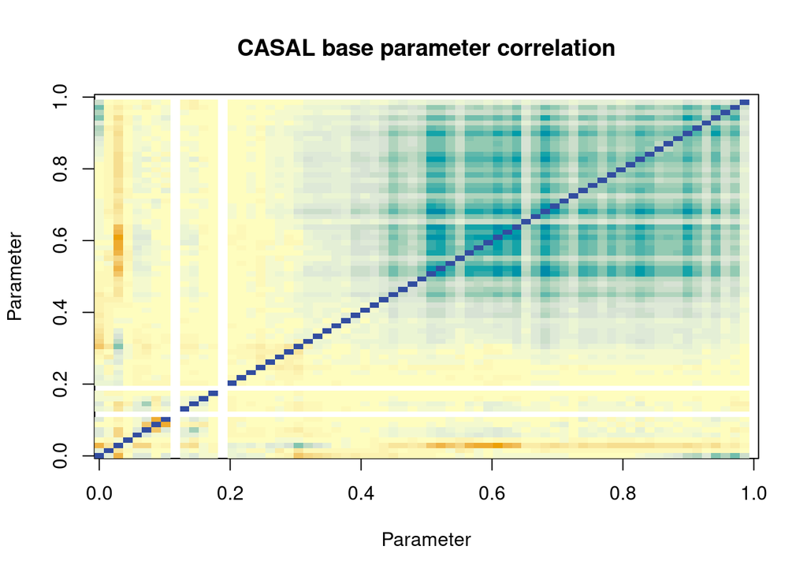

```
## [1] "CASAL base parameter correlation range (excluding 1.0): -0.4892 0.7574"
```

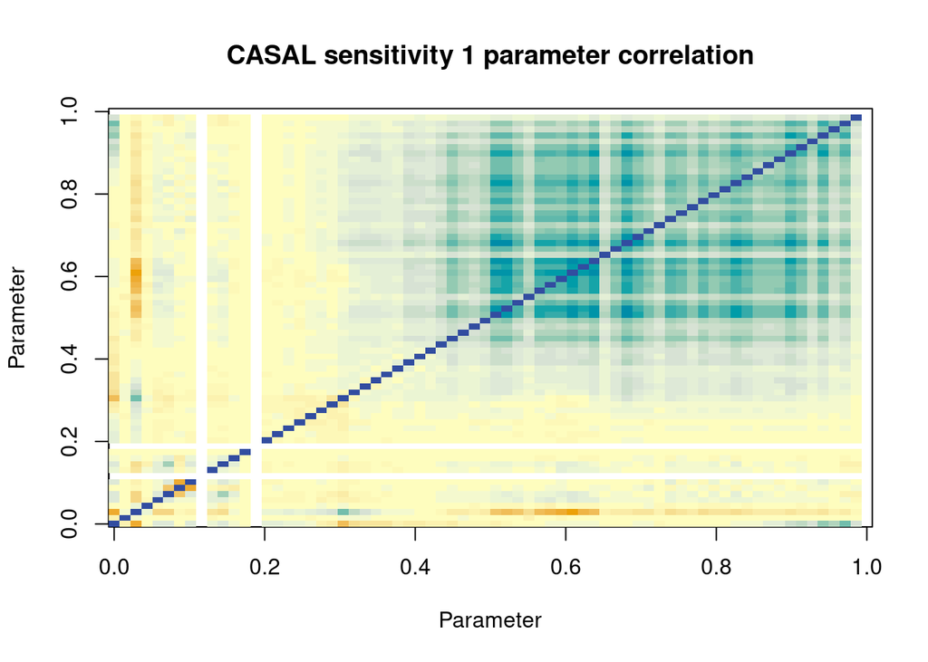

```
## [1] "CASAL sensitivity 1 parameter correlation range (excluding 1.0): -0.4792 0.7563"
```

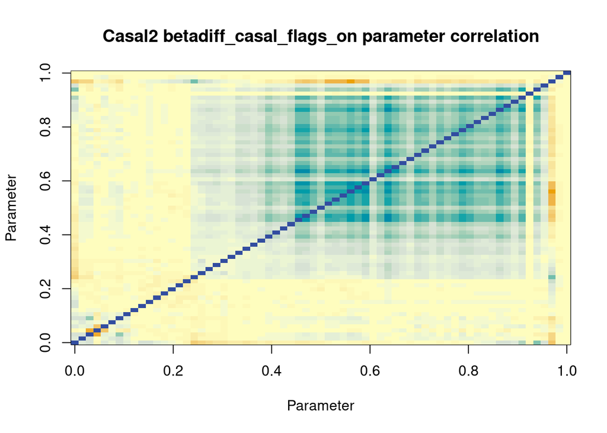

```
## [1] "Casal2 betadiff_casal_flags_on parameter correlation range (excluding 1.0): -0.458675 0.753614"
```

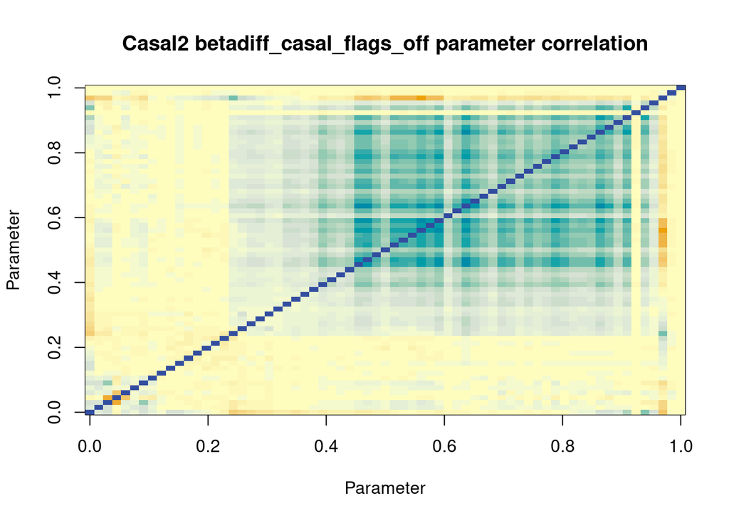

```
## [1] "Casal2 betadiff_casal_flags_off parameter correlation range (excluding 1.0): -0.458675 0.753614"
```

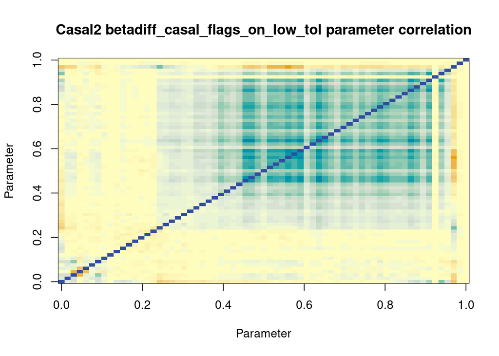

```
## [1] "Casal2 betadiff_casal_flags_on_low_tol parameter correlation range (excluding 1.0): -0.458267 0.755137"
```

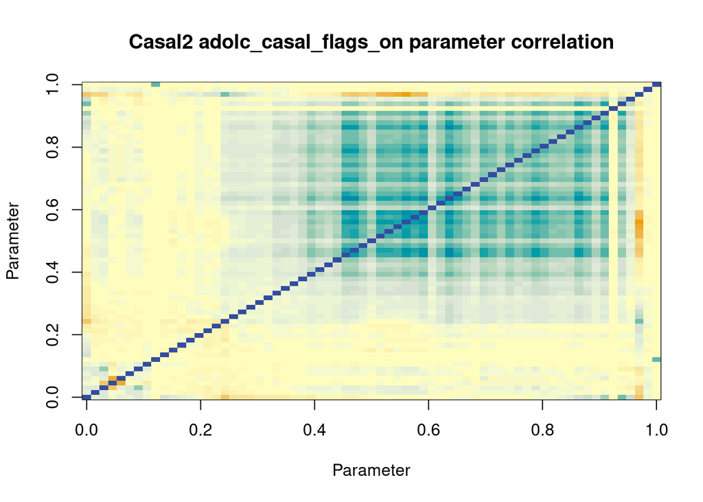

```
## [1] "Casal2 adolc_casal_flags_on parameter correlation range (excluding 1.0): -0.471093 0.763113"
```

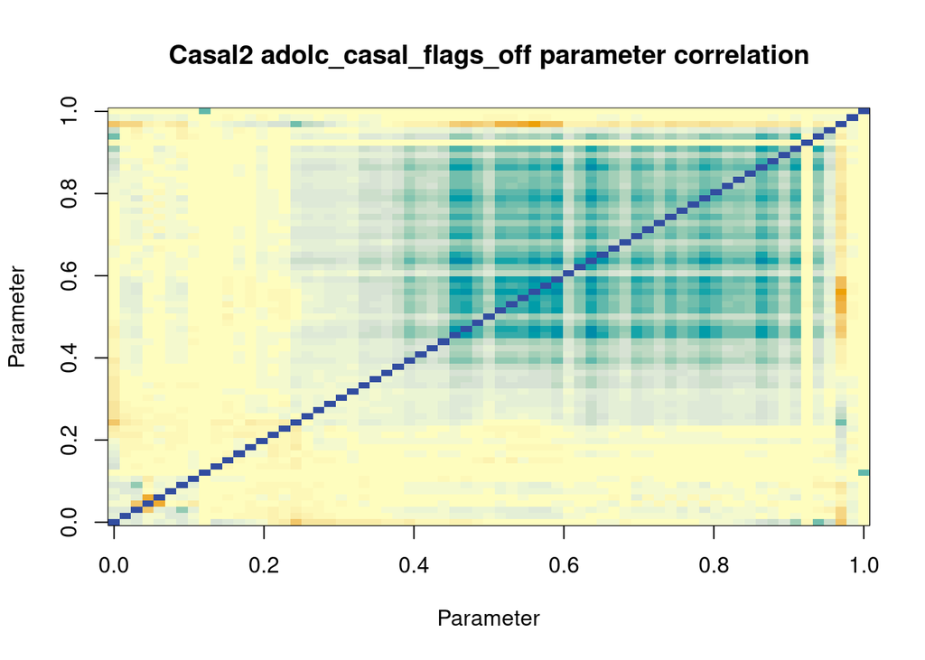

```
## [1] "Casal2 adolc_casal_flags_off parameter correlation range (excluding 1.0): -0.471093 0.763113"
```

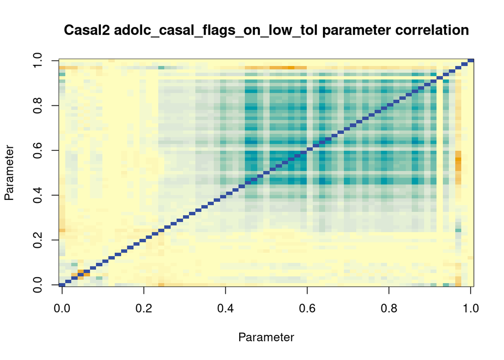

```
## [1] "Casal2 adolc_casal_flags_on_low_tol parameter correlation range (excluding 1.0): -0.471066 0.763093"
```

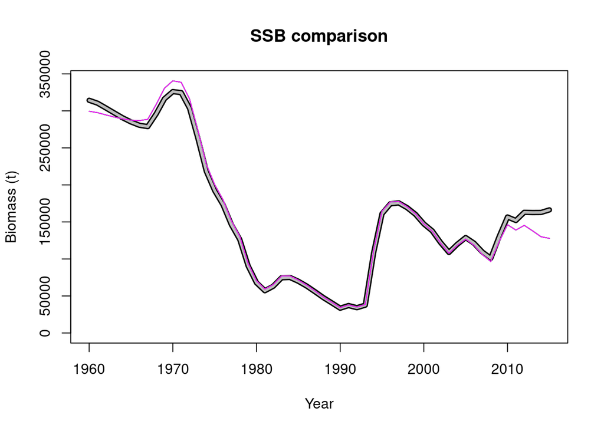

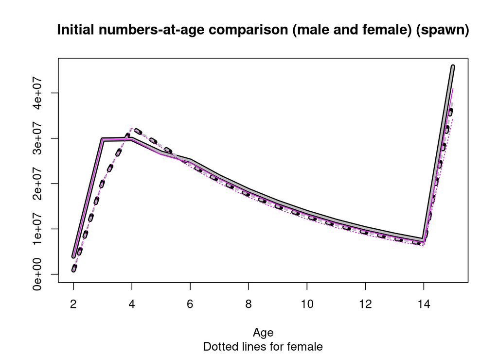

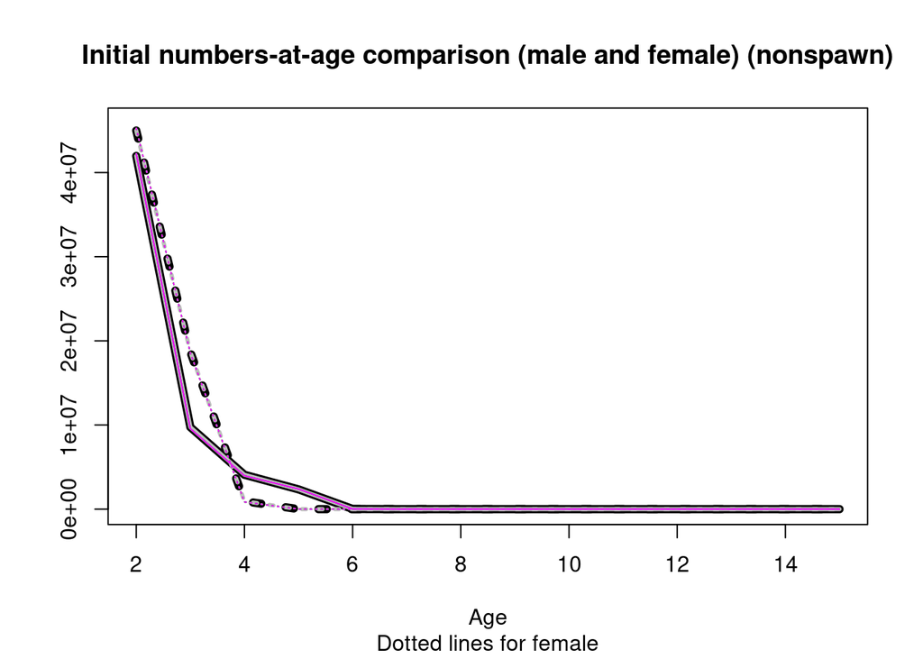

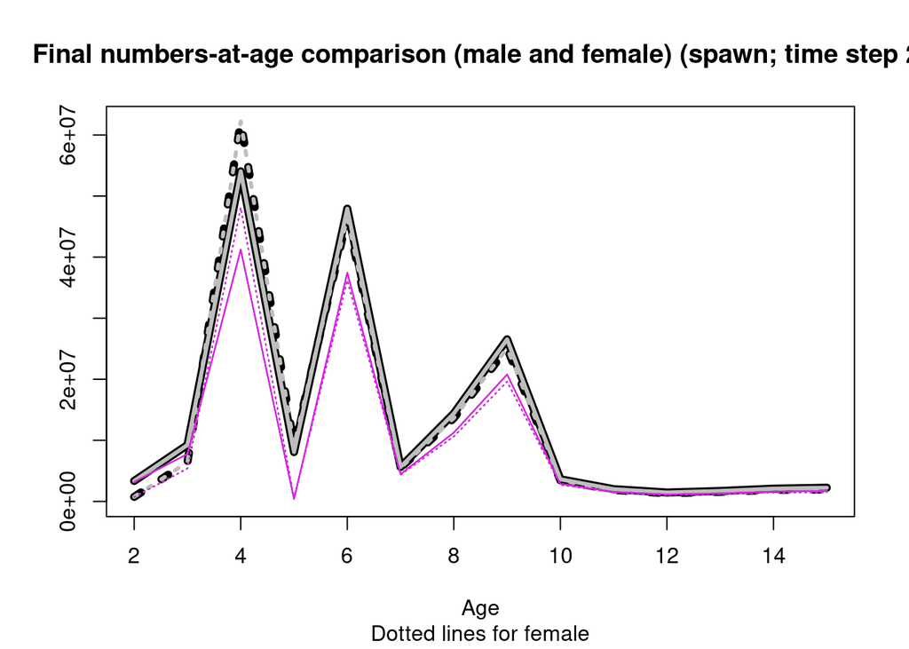

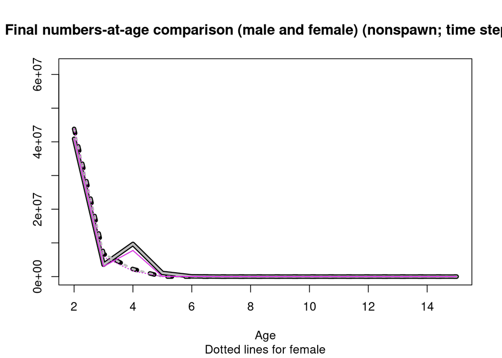

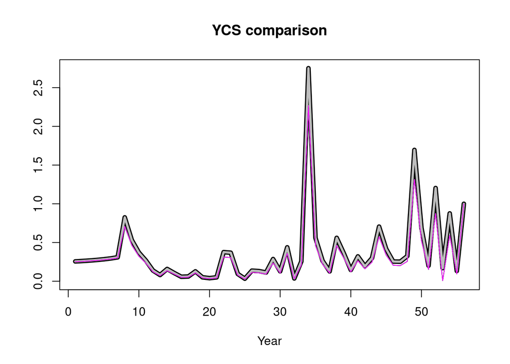

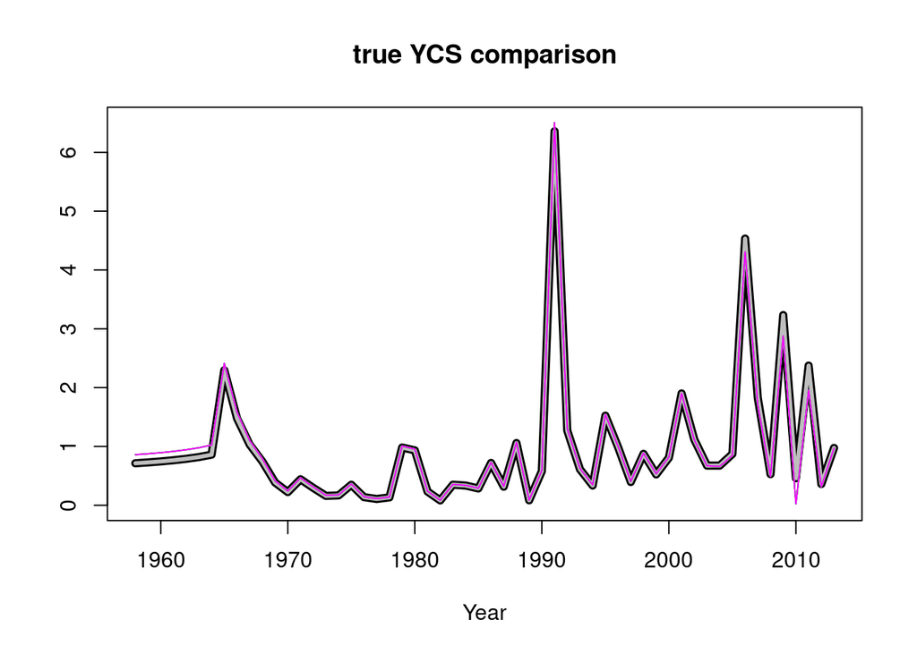

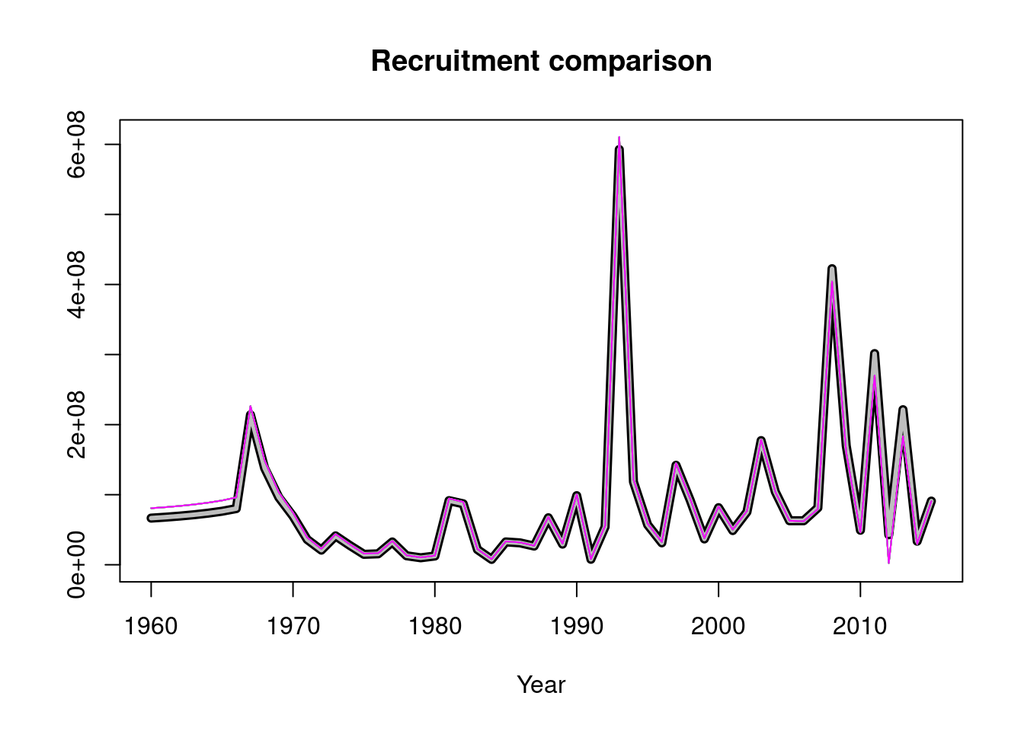

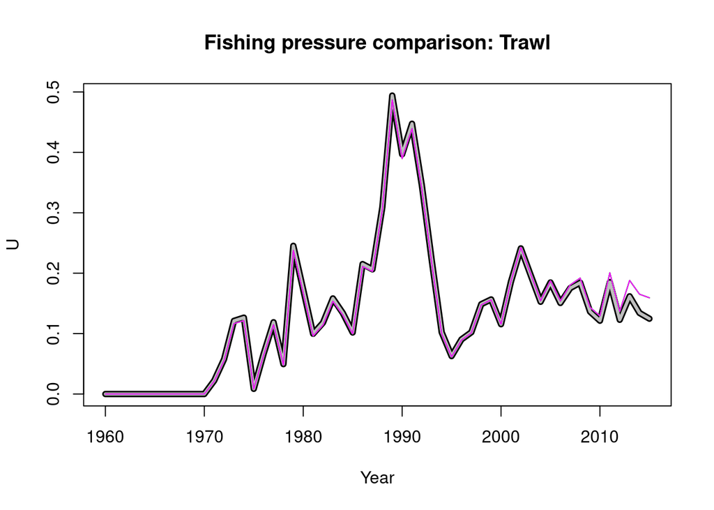

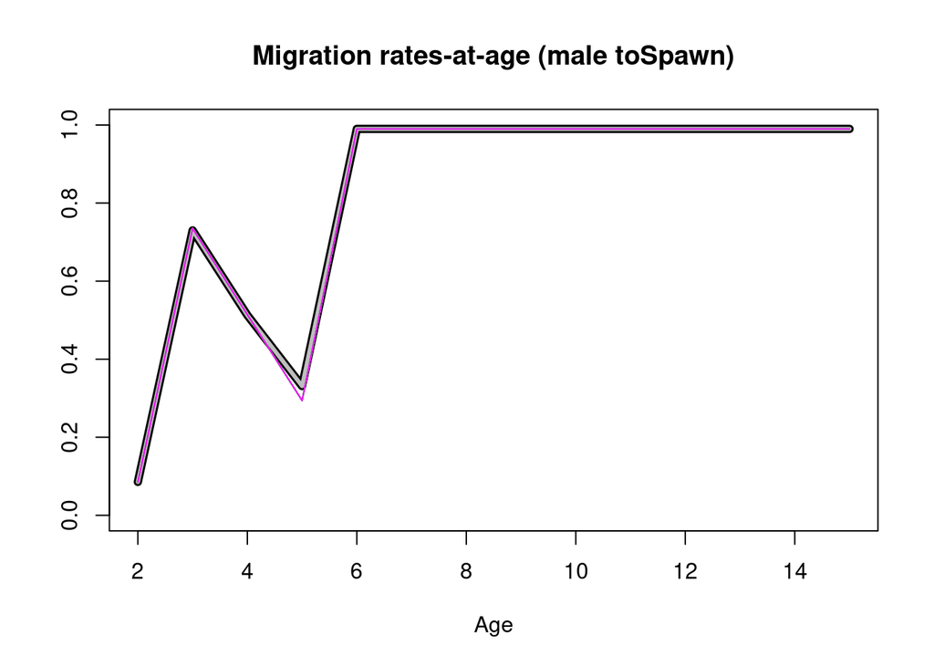

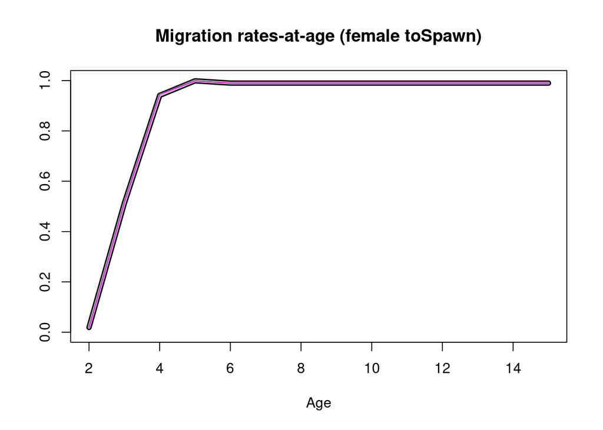